# GR5243 Project1 by Xuehan Liu (xl2615)

#### Introduction

The president election in the US has been the hottest topic in the past few months. The competition between Repbulican party and Democratic party is accelerated. In order to understands more about Repbulican and Democratic, we will looking at the inaugural speeches that given by previous presidents from these two parties. There will be two major questions we can answer with this project: 1) Do Repbulican and Democratic focus on different aspects? and 2) For those who are considered as typical representative for each party, what sentiments they carries in their inaugural speeches? Is there any difference for two parties? With the answer to both questions, we will have a deeper understanding how well both the Repbulican and Democratic do to integrate their parties’ philosophy.

### Loading Data, Packages and Cleaning Up

Before we are doing any analysis, we load relative packages and text files into R.

```r
packages.used=c("rvest", "tibble", "qdap",
                "sentimentr", "gplots", "dplyr",
                "tm", "syuzhet", "factoextra",
                "beeswarm", "scales", "RColorBrewer",
                "RANN", "tm", "topicmodels")
# check packages that need to be installed.
packages.needed=setdiff(packages.used,
                        intersect(installed.packages()[,1],
                                  packages.used))
# install additional packages
if(length(packages.needed)>0){
  install.packages(packages.needed, dependencies = TRUE)
}
library("rvest")
library("tibble")
library("qdap")
library("sentimentr")
library("gplots")
library("dplyr")
library("tm")
library("syuzhet")
library("factoextra")
library("beeswarm")
library("scales")
library("RColorBrewer")
library("RANN")
library("tm")
library("topicmodels")
library("wordcloud")
inaug.list<-read.csv("/Users/xuehan/Desktop/5243 ADS/Spr2017-Proj1-XuehanLiu/data/inauglist.csv", stringsAsFactors = FALSE)
nomin.list<-read.csv("/Users/xuehan/Desktop/5243 ADS/Spr2017-Proj1-XuehanLiu/data/nominlist.csv", stringsAsFactors = FALSE)
farewell.list<-read.csv("/Users/xuehan/Desktop/5243 ADS/Spr2017-Proj1-XuehanLiu/data/farewelllist.csv", stringsAsFactors = FALSE)
speech.list=rbind(inaug.list, nomin.list, farewell.list)
speech.list$type=c(rep("inaug", nrow(inaug.list)),
                   rep("nomin", nrow(nomin.list)),
                   rep("farewell", nrow(farewell.list)))
speech.url=rbind(inaug.list, nomin.list, farewell.list)
speech.list=cbind(speech.list, speech.url)
#Load the speeches:
folder.path<-file.path("/Users/xuehan/Desktop/5243 ADS/Spr2017-Proj1-XuehanLiu/data/InauguralSpeeches/")
#speeches<-list.files(path = folder.path, pattern = "*.txt")
text<-Corpus(DirSource(folder.path))
```

### Propotion of Repbulican and Democratic in the political parties in US.

As we all know, Republican and Democratic are the two biggest parties in the America. So our focus is going to be only these two parties. Before jump into the conclusion stated directly, we can use some graphical and numerical tool to confirm this statement.

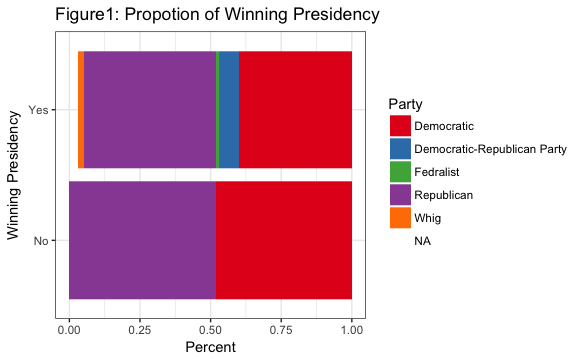

```r
library(ggplot2)
speech.list$Party<-as.factor(speech.list$Party)
speech.list$Win<-as.factor(speech.list$Win)
levels(speech.list$Win)[1]<-"No"
levels(speech.list$Win)[2]<-"Yes"
ggplot(aes(x=Win,fill=Party),data=speech.list)+geom_bar(position="fill")+scale_fill_brewer(palette="Set1")+xlab("Winning Presidency")+ylab("Percent")+coord_flip()+theme_bw()+ggtitle("Figure1: Propotion of Winning Presidency")+theme(plot.title=element_text(lineheight=.8))
```

```r
table(as.factor(inaug.list$Party))/length(inaug.list$Party)
```

```
                 Democratic Democratic-Republican Party
                 0.37931034                  0.12068966
                  Fedralist                  Republican
                 0.01724138                  0.41379310
                       Whig
                 0.03448276
```

#### Question 1: Do Repbulican and Democratic focus on different aspects?

In this question, we use wordcloud method to illustrate important aspects that presidents may cover in their inaugural speeches by extracting keys words. These key words contains the main philosophy of the party a president represents.

Before going to either Repubilican or Democratic directly, let us look at the overall wordcloud for inaugural speeches.

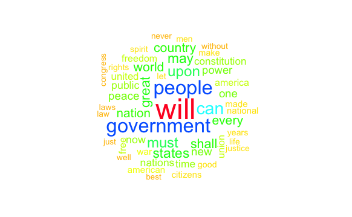

```r
text <- tm_map(text, content_transformer(tolower))
text<-tm_map(text, removeWords, stopwords("english"))
text <- tm_map(text, stripWhitespace)
text <- tm_map(text, removeWords, character(0))
text<-tm_map(text, removePunctuation)
text <- tm_map(text, PlainTextDocument)
#Check the overall wordcloud first:
wordcloud(text,random.order=F,scale=c(3,0.5),max.word=50,colors=rainbow(40))
```

One thing we can use this overall wordcloud for is to continue removing unuseful words in the speeches. Based on the wordcloud above, we probably should eliminate words like “will, people, government, shall, may, must, made, world”,etc. We can repeat this step many times and finally choose the set of words that looks most useful and meaningful to you.

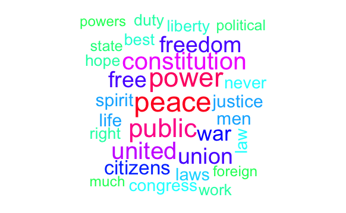

```r
#Remove unuseful words mentioned above
text<-tm_map(text, removeWords, c("will","people", "government","shall", "may", "must","made", "world","can","every","country","now","good","upon","states","nation","nations","america","great","national","rights","one","let","new","the","make","without","american","well","time","among","know","years","just","many"))
#New Wordcloud:
wordcloud(text,random.order=F,scale=c(3,0.5),max.word=30,colors=rainbow(40))
```

From the above wordcloud image, most of the words actually make sense. So we can start the comparison for Republican party and Democratic party from here.

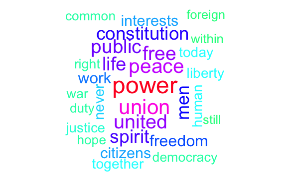

```r
#Extract speeches for Democratic
#First find presidents who are Democratic:
demop<-inaug.list[which(inaug.list$Party=="Democratic"),]$President
#length(demop)
#Totally there should be 22 presidents
demo<-text[c(3:6,12:16,22:24,26,28,33,35,37,38,52,53,56,57)]
#Extract speeches for Republican
repp<-inaug.list[which(inaug.list$Party=="Republican"),]$President
repub<-text[c(1,2,7:11,17,20,21,25,27,39:44,47:49,51,54,55)]
#Check out the wordcloud of most frequent words for Democratic
wordcloud(demo,random.order=F,scale=c(3,0.5),max.word=30,colors=rainbow(40))
```

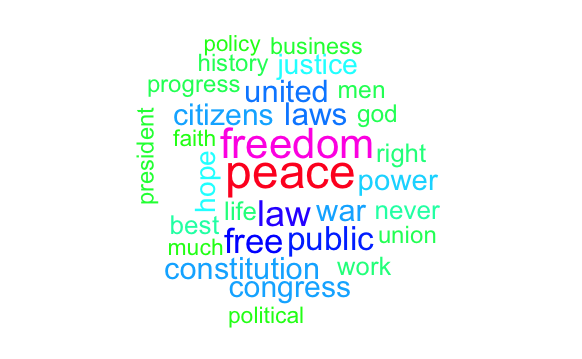

```r
wordcloud(repub,random.order=F,scale=c(3,0.5),max.word=30,colors=rainbow(40))
```

#### Question 2: For each party (Repubilican and Democratic), for those who are considered as “best” (representative) presidents in the history, what is the difference in sentiments/emotions in their inaugural speeches?

According to the article published in the website mademan.com, (http://www.mademan.com/mm/5-best-democratic-presidents.html) and (http://www.mademan.com/mm/5-best-republican-presidents.html), we choose five presidents for each party, listed as following:

Repubilican: Abraham Lincoln, Ulysses S. Grant, Theodore Roosevelt, Dwight D. Eisenhower, Ronald Reagan

Democratic: Franklin D. Roosevelt, Woodrow Wilson, Andrew Jackson, Harry S. Truman, and John F. Kennedy

We will study the inaugural speeches from these ten presidents and conduct the sentiment analysis.

### 2a.Generate sentences list by code given in the prof. Zheng’s tutorial 2:

```r
### Inauguaral speeches
main.page <- read_html(x = "http://www.presidency.ucsb.edu/inaugurals.php")
# Get link URLs
# f.speechlinks is a function for extracting links from the list of speeches.
inaug=f.speechlinks(main.page)
#head(inaug)
as.Date(inaug[,1], format="%B %e, %Y")
```

```
 [1] "1789-04-30" "1793-03-04" "1797-03-04" "1801-03-04" "1805-03-04"
 [6] "1809-03-04" "1813-03-04" "1817-03-04" "1821-03-04" "1825-03-04"
[11] "1829-03-04" "1833-03-04" "1837-03-04" "1841-03-04" "1845-03-04"
[16] "1849-03-05" "1853-03-04" "1857-03-04" "1861-03-04" "1865-03-04"
[21] "1869-03-04" "1873-03-04" "1877-03-05" "1881-03-04" "1885-03-04"
[26] "1889-03-04" "1893-03-04" "1897-03-04" "1901-03-04" "1905-03-04"
[31] "1909-03-04" "1913-03-04" "1917-03-04" "1921-03-04" "1925-03-04"
[36] "1929-03-04" "1933-03-04" "1937-01-20" "1941-01-20" "1945-01-20"
[41] "1949-01-20" "1953-01-20" "1957-01-21" "1961-01-20" "1965-01-20"
[46] "1969-01-20" "1973-01-20" "1977-01-20" "1981-01-20" "1985-01-21"
[51] "1989-01-20" "1993-01-20" "1997-01-20" "2001-01-20" "2005-01-20"
[56] "2009-01-20" "2013-01-21" "2017-01-20" NA
```

```r
inaug=inaug[-nrow(inaug),] # remove the last line, irrelevant due to error.
#### Nomination speeches
main.page=read_html("http://www.presidency.ucsb.edu/nomination.php")
# Get link URLs
nomin <- f.speechlinks(main.page)
#head(nomin)
#
#### Farewell speeches
main.page=read_html("http://www.presidency.ucsb.edu/farewell_addresses.php")
# Get link URLs
farewell <- f.speechlinks(main.page)
#head(farewell)
```

```r
speech.list$fulltext=NA
for(i in seq(nrow(speech.list))) {
  text <- read_html(speech.list$urls[i]) %>% # load the page
    html_nodes(".displaytext") %>% # isloate the text
    html_text() # get the text
  speech.list$fulltext[i]=text
  # Create the file name
  filename <- paste0("/Users/xuehan/Desktop/5243 ADS/Spr2017-Proj1-XuehanLiu/data/",
                     speech.list$type[i],
                     speech.list$File[i], "-",
                     speech.list$Term[i], ".txt")
  sink(file = filename) %>% # open file to write
  cat(text)  # write the file
  sink() # close the file
}
```

```r
sentence.list=NULL
for(i in 1:nrow(speech.list)){
  sentences=sent_detect(speech.list$fulltext[i],
                        endmarks = c("?", ".", "!", "|",";"))
  if(length(sentences)>0){
    emotions=get_nrc_sentiment(sentences)
    word.count=word_count(sentences)
    # colnames(emotions)=paste0("emo.", colnames(emotions))
    # in case the word counts are zeros?
    emotions=diag(1/(word.count+0.01))%*%as.matrix(emotions)
    sentence.list=rbind(sentence.list,
                        cbind(speech.list[i,-ncol(speech.list)],
                              sentences=as.character(sentences),
                              word.count,
                              emotions,
                              sent.id=1:length(sentences)
                              )
    )
  }
}
```

[output not shown]

```r
sentence.list=sentence.list%>%filter(!is.na(word.count))
```

### 2b.Conduct the Analysis

```r
#Creat a subset that contains five Repubilican presidents mentioned above
#Extract sentiment score for five presidents:
AL<-na.omit(sentence.list[which(sentence.list$President=="Abraham Lincoln"),13:22])
UG<-na.omit(sentence.list[which(sentence.list$President=="Ulysses S. Grant"),13:22])
TR<-na.omit(sentence.list[which(sentence.list$President=="Theodore Roosevelt"),13:22])
DE<-na.omit(sentence.list[which(sentence.list$President=="Dwight D. Eisenhower"),13:22])
RR<-na.omit(sentence.list[which(sentence.list$President=="Ronald Reagan"),13:22])
#Average sentiment scores for five presidents:
als<-apply(AL,2,mean)
ugs<-apply(UG,2,mean)
trs<-apply(TR,2,mean)
des<-apply(DE,2,mean)
rrs<-apply(RR,2,mean)
#####################################################################################
####Then we can record this information in a speard sheet in Excel for future use.###
####When try to reproduce this project, please remeber to download and use ##########
########################sscore.csv file. ############################################
#####################################################################################
#Repeat the same step as above for five Democratic Presidents:
FR<-na.omit(sentence.list[which(sentence.list$President=="Franklin D. Roosevelt"),13:22])
WW<-na.omit(sentence.list[which(sentence.list$President=="Woodrow Wilson"),13:22])
AJ<-na.omit(sentence.list[which(sentence.list$President=="Andrew Jackson"),13:22])
HT<-na.omit(sentence.list[which(sentence.list$President=="Harry S. Truman"),13:22])
JK<-na.omit(sentence.list[which(sentence.list$President=="John F. Kennedy"),13:22])
frs<-apply(FR,2,mean)
wws<-apply(WW,2,mean)
ajs<-apply(AJ,2,mean)
hts<-apply(HT,2,mean)
jks<-apply(JK,2,mean)
```

### Use the sentiment score data

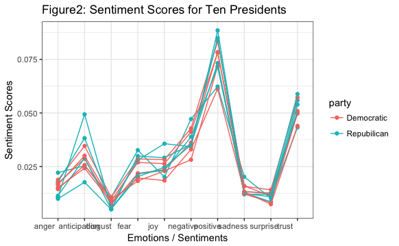

```r
#Load the sentiment score data:
sscore<-read.csv("/Users/xuehan/Desktop/5243 ADS/Spr2017-Proj1-XuehanLiu/data/sentiment score.csv")
sscore$score<-as.numeric(sscore$score)
sscore$type<-as.factor(sscore$type)
sscore$party<-as.factor(sscore$party)
sscore$President<-as.factor(sscore$President)
#Plot of those sentiments scores:
ggplot(data=sscore,aes(x=type,y=score,colour=party,group=President))+
  geom_point()+geom_line()+ggtitle("Figure2: Sentiment Scores for Ten Presidents")+theme_bw()+labs(x="Emotions / Sentiments",y="Sentiment Scores")
```

First observation I can make is that all presidents showed a very posotive attitude in their inaugural speeches. It is also make sense that “trust” is the second most popular emotion in the speech. However, it surprises me that the score for joy and fear are about the same, which means that in the speeches these two emotions weight about the same.